# Visualization of star wars dataset using ggplot2

Lars Relund Nielsen

2023-11-15

## What’s in the Star Wars data?

- How many rows and columns does this dataset have?
- What does each row represent?
- What does each column represent?

```r
library(tidyverse)
# ?starwars
glimpse(starwars)
```

```
## Rows: 87
## Columns: 14
## $ name       <chr> "Luke Skywalker", "C-3PO", "R2-D2", "Darth Vader", "Leia Organa", "Owen Lars", …
## $ height     <int> 172, 167, 96, 202, 150, 178, 165, 97, 183, 182, 188, 180, 228, 180, 173, 175, 1…
## $ mass       <dbl> 77.0, 75.0, 32.0, 136.0, 49.0, 120.0, 75.0, 32.0, 84.0, 77.0, 84.0, NA, 112.0, …
## $ hair_color <chr> "blond", NA, NA, "none", "brown", "brown, grey", "brown", NA, "black", "auburn,…
## $ skin_color <chr> "fair", "gold", "white, blue", "white", "light", "light", "light", "white, red"…
## $ eye_color  <chr> "blue", "yellow", "red", "yellow", "brown", "blue", "blue", "red", "brown", "bl…
## $ birth_year <dbl> 19.0, 112.0, 33.0, 41.9, 19.0, 52.0, 47.0, NA, 24.0, 57.0, 41.9, 64.0, 200.0, 2…
## $ sex        <chr> "male", "none", "none", "male", "female", "male", "female", "none", "male", "ma…
## $ gender     <chr> "masculine", "masculine", "masculine", "masculine", "feminine", "masculine", "f…
## $ homeworld  <chr> "Tatooine", "Tatooine", "Naboo", "Tatooine", "Alderaan", "Tatooine", "Tatooine"…
## $ species    <chr> "Human", "Droid", "Droid", "Human", "Human", "Human", "Human", "Droid", "Human"…
## $ films      <list> <"The Empire Strikes Back", "Revenge of the Sith", "Return of the Jedi", "A Ne…
## $ vehicles   <list> <"Snowspeeder", "Imperial Speeder Bike">, <>, <>, <>, "Imperial Speeder Bike",…
## $ starships  <list> <"X-wing", "Imperial shuttle">, <>, <>, "TIE Advanced x1", <>, <>, <>, <>, "X-…
```

## Scatterplot of mass vs. height

```
## Warning: Removed 28 rows containing missing values (`geom_point()`).
```

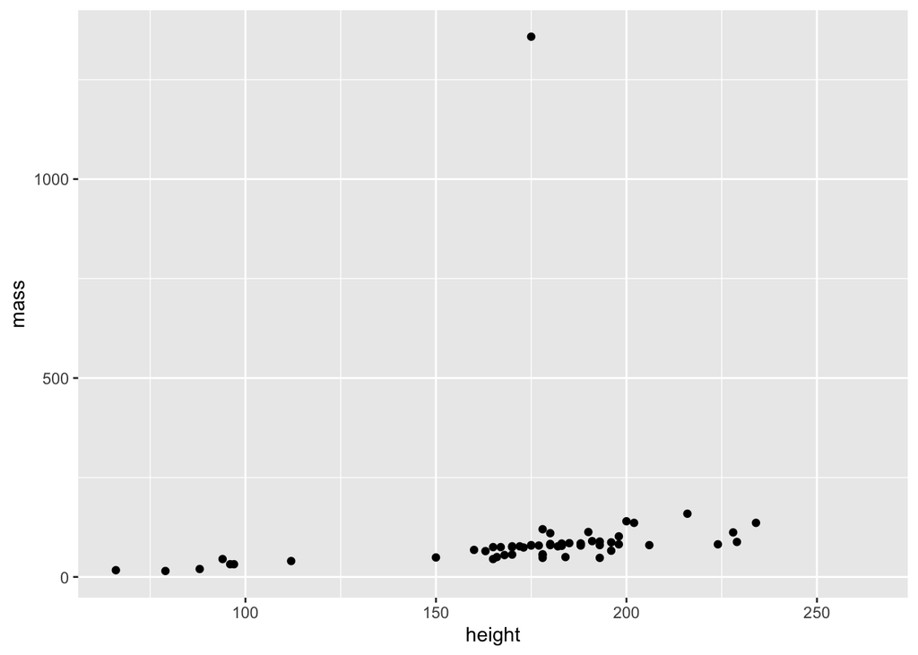

```r
ggplot(data = starwars, mapping = aes(x = height, y = mass)) +
  geom_point()
```

Note a warning is issued. Not all characters have height and mass information (hence 28 of them not plotted). You may exclude warnings in chunk output by using option `warning = FALSE`. However, but often it’s important to note it.

### Adding labels

The `labs` function can be used to add different labels to the plot.

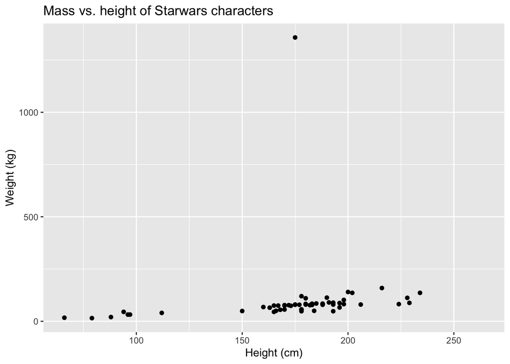

```r
ggplot(data = starwars, mapping = aes(x = height, y = mass)) +
  geom_point() +
  labs(title = "Mass vs. height of Starwars characters",
       x = "Height (cm)", y = "Weight (kg)")
```

### The fat guy

- How would you describe this relationship?
- What other variables would help us understand data points that don’t follow the overall trend?
- Who is the not so tall but really chubby character?

```r
dat <- starwars %>%
  filter(mass > 500) %>%
  select(name, height, mass)
```

The fat guy is Jabba Desilijic Tiure

## Aesthetics

Visual characteristics of plotting can be **mapped to a specific variable** using aesthetics. For instance, the visual characteristics of plotting points are:

- `color`
- `size`
- `shape`
- `alpha` (transparency)

Let us have a look at mass vs. height using gender as color aesthetic:

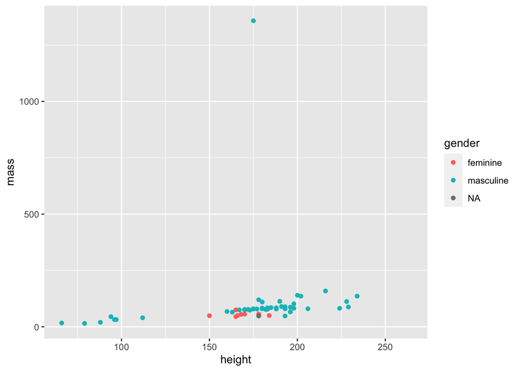

```r
ggplot(data = starwars,
       mapping = aes(x = height, y = mass, color = gender)) +
  geom_point()
```

In general not many girls in star wars. Let us add birth year as size aesthetic:

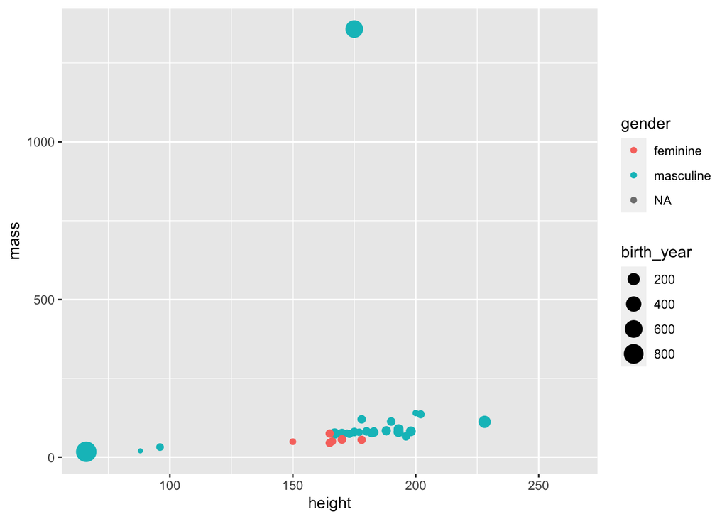

```r
ggplot(data = starwars,
       mapping = aes(x = height, y = mass, color = gender, size = birth_year)) +
  geom_point()
```

Jabba is very old. What about species? We use species as color aesthetic:

```r
#Your turn - Finish the code
ggplot(data = starwars,
       mapping = aes(x=height, y = mass, color = species, size = birth_year)) +
  geom_point()
```

[output not shown]

Let’s now increase the size of all points **not** based on the values of a variable in the data:

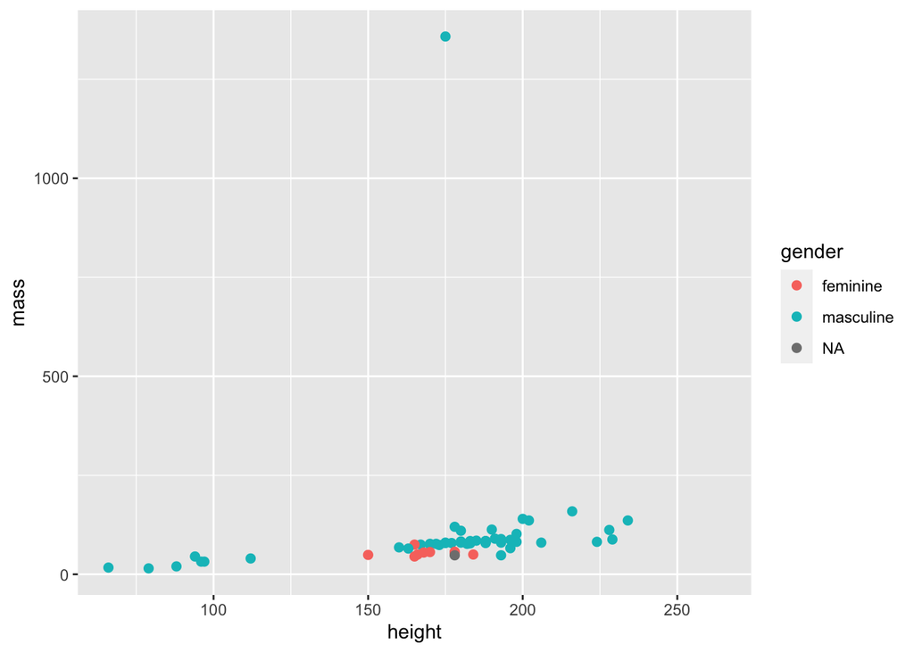

```r
ggplot(data = starwars, mapping = aes(x = height, y = mass, color = gender)) +
  geom_point(size = 2)
```

```r
#Your turn: finish the code
ggplot(data = starwars, mapping = aes(x = height, y = mass, color = hair_color)) +
  geom_point(shape=2)
```

[output not shown]

**Summary**

- Continuous variables are measured on a continuous scale.
- Discrete variables are measured (or often counted) on a discrete scale.
- Use aesthetics for mapping features of a plot to a variable.
- Define fixed features in the geom outside the `aes` function.

| aesthetics | discrete | continuous |
| --- | --- | --- |
| color | rainbow of colors | gradient |
| size | discrete steps | linear mapping between radius and value |
| shape | different shape for each | shouldn’t (and doesn’t) work |

## Facet plots

- Smaller plots that display different subsets of the data.
- Useful for exploring conditional relationships and large data.

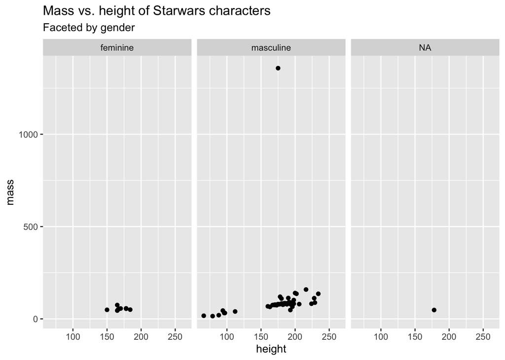

```r
ggplot(data = starwars, mapping = aes(x = height, y = mass)) +
  facet_grid(. ~ gender) +  # or use rows/cols argument
  geom_point() +
  labs(title = "Mass vs. height of Starwars characters",
       subtitle = "Faceted by gender")
```

- Describe what each plot displays.
- Think about how the code relates to the output.

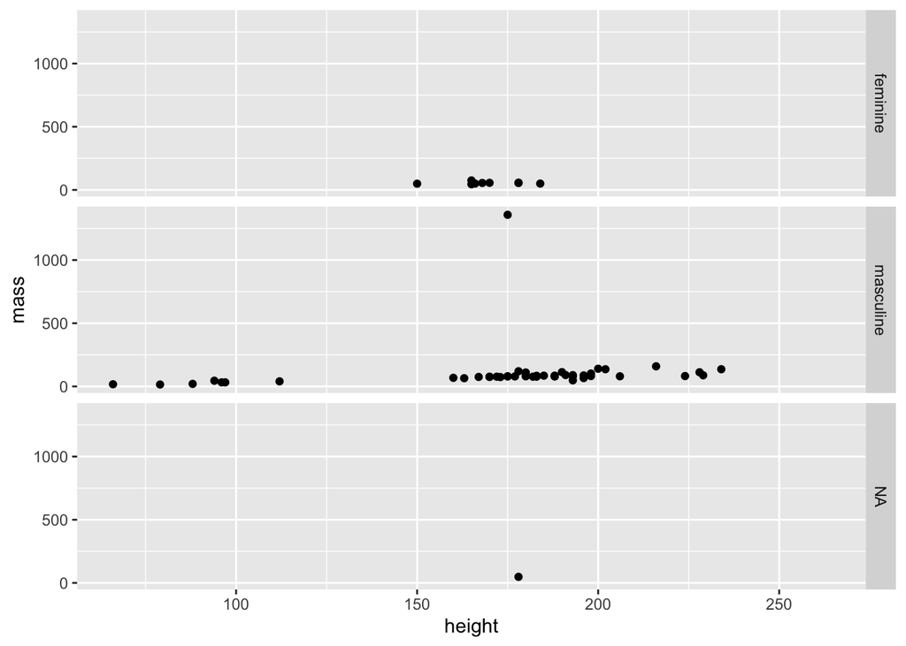

```r
ggplot(data = starwars, mapping = aes(x = height, y = mass)) +
  geom_point() +
  facet_grid(gender ~ .)
```

Each subset will display a column of genders with each row representing a gender. This is because the ~ is after gender (the first argument in facet grid). If it was before, then it would make a column for each.

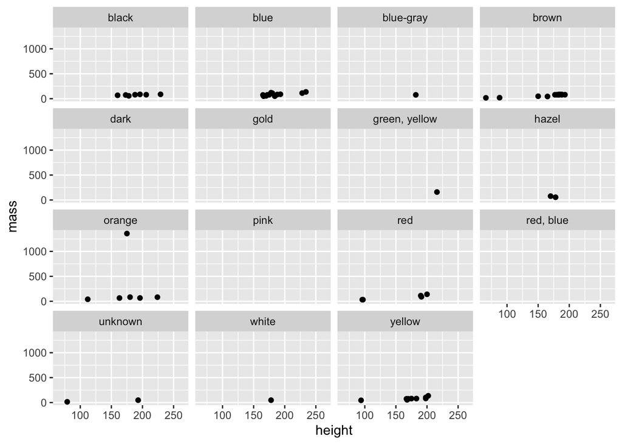

```r
ggplot(data = starwars, mapping = aes(x = height, y = mass)) +
  geom_point() +
  facet_wrap(~ eye_color)
```

Let us facet species:

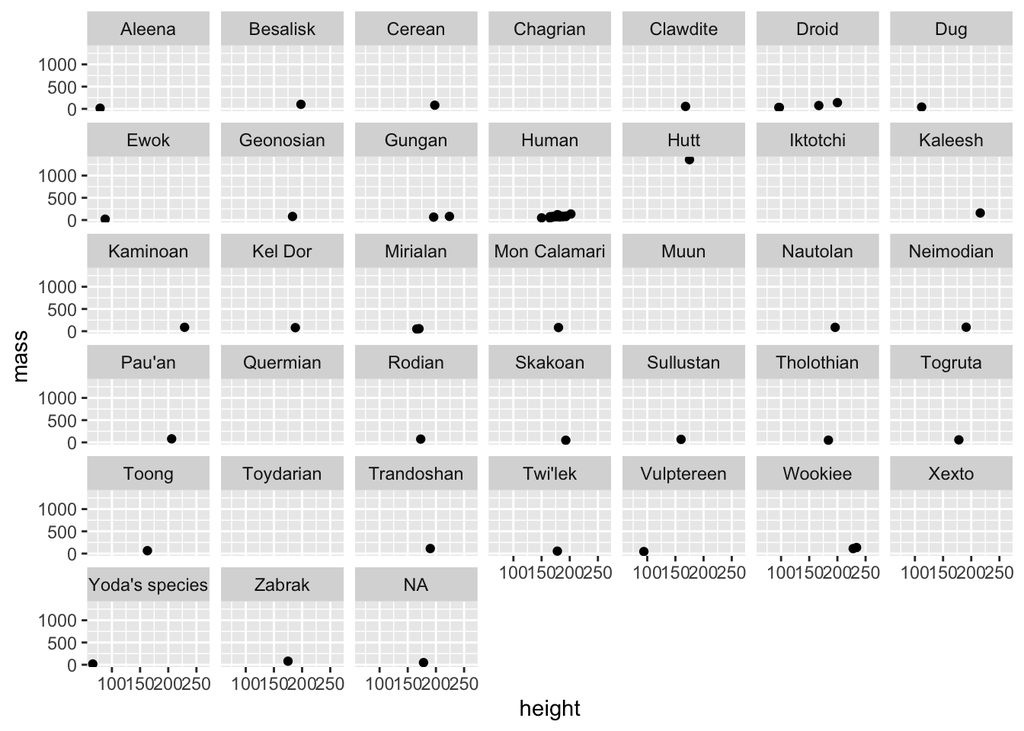

```r
ggplot(data = starwars, mapping = aes(x = height, y = mass)) +
  geom_point() +
  facet_wrap(~ species)
```

**Summary**

- `facet_grid()`:
  - 2d grid can be made by facet grid.
  - `rows ~ cols`
  - use `.` for no split
- `facet_wrap()`: 1d ribbon wrapped into 2d. To make them square.

## Identifying variables and plot type

- Univariate data analysis - distribution of single variable
- Bivariate data analysis - relationship between two variables
- Multivariate data analysis - relationship between many variables at once, usually focusing on the relationship between two while conditioning for others

There are different variable types:

- **Numerical variables** can be classified as **continuous** or **discrete** based on whether or not the variable can take on an infinite number of values or only non-negative whole numbers, respectively.
- If the variable is **categorical**, we can determine if it is **ordinal** based on whether or not the levels have a natural ordering.

## Visualizing numerical data

Describing shapes of numerical distributions

- shape:
  - skewness: right-skewed, left-skewed, symmetric (skew is to the side of the longer tail)
  - modality: unimodal, bimodal, multimodal, uniform
- center: mean (`mean`), median (`median`), mode (not always useful)
- spread: range (`range`), standard deviation (`sd`), inter-quartile range (`IQR`)
- unusal observations

### Histograms

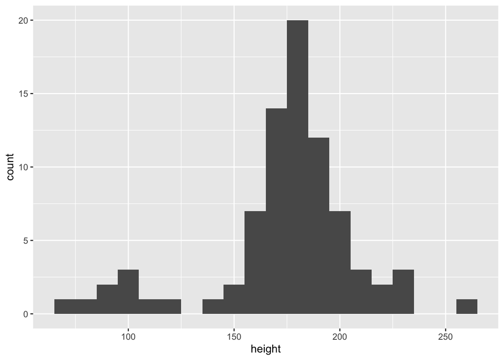

```r
ggplot(data = starwars, mapping = aes(x = height)) +
  geom_histogram(binwidth = 10)
```

### Density plots

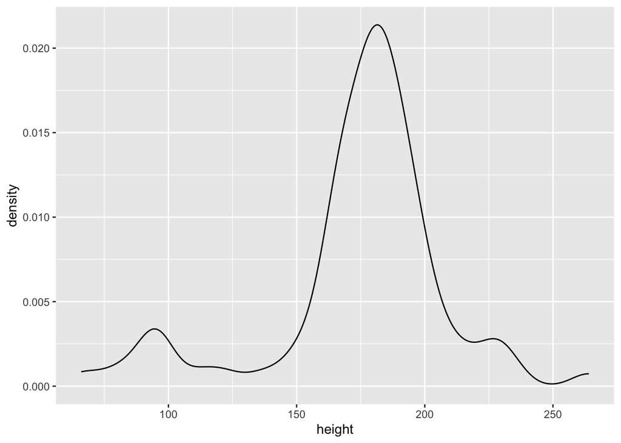

```r
ggplot(data = starwars, mapping = aes(x = height)) +
  geom_density()
```

## Visualizing categorical data

### Bar plots

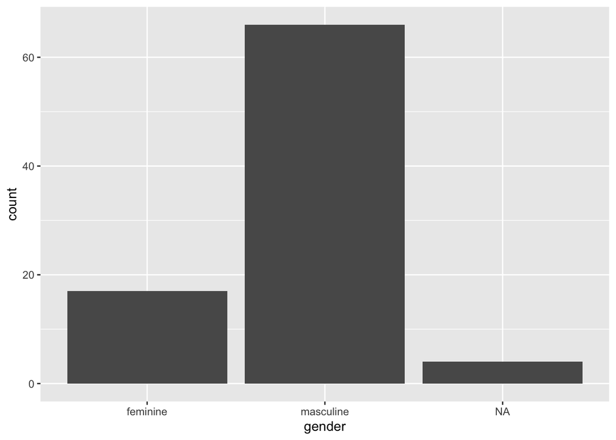

```r
ggplot(data = starwars, mapping = aes(x = gender)) +
  geom_bar()
```

### Segmented bar plots, counts

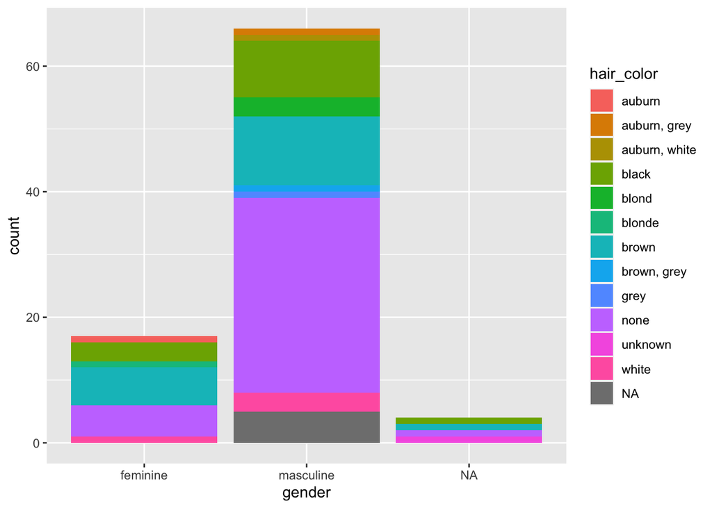

```r
ggplot(data = starwars, mapping = aes(x = gender, fill = hair_color)) +
  geom_bar()
```

Let us recode hair color into a smaller set:

```r
starwars <- starwars %>%
  mutate(hair_color2 =
           fct_other(hair_color,
                     keep = c("black", "brown", "blond")
                     )
         )
```

The segmented bar plot now becomes

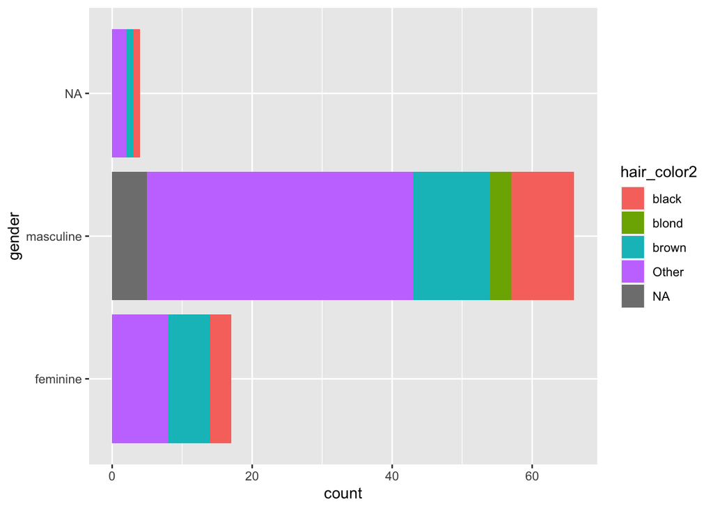

```r
#Your turn - Finish the code
ggplot(data = starwars,
       mapping = aes(x = gender, fill = hair_color2)) +
  geom_bar() +
  coord_flip()
```

Try to run the following:

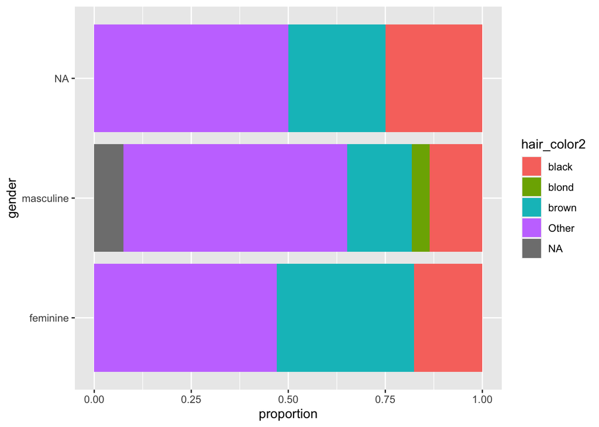

```r
ggplot(data = starwars,
       mapping = aes(x = gender, fill = hair_color2)) +
  geom_bar(position = "fill") +
  coord_flip() +
  labs(y = "proportion")
```

Position = “fill” gør at andelene bliver udregnet for hver gruppering. Ikke repræsentativ ift at sammenligne om der er flere med den ene hårfarve mænd end den anden. Men rigtig god til at visualisere forholdet mellem køn og hårfarve.

Which bar plot is a more useful representation for visualizing the relationship between gender and hair color?

## Visualizing relationships between numerical and categorical data

### Side-by-side box plotskayle

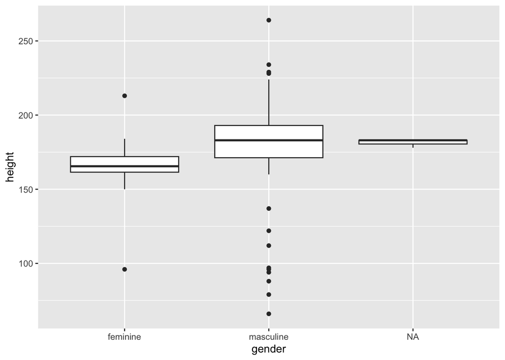

```r
ggplot(data = starwars, mapping = aes(y = height, x = gender)) +
  geom_boxplot()
```

### Scatter plot…

This is not a great representation of these data.

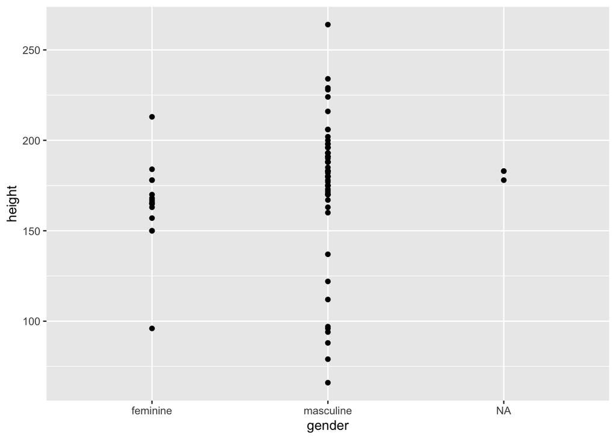

```r
ggplot(data = starwars, mapping = aes(y = height, x = gender)) +
  geom_point()
```

### Violin plots

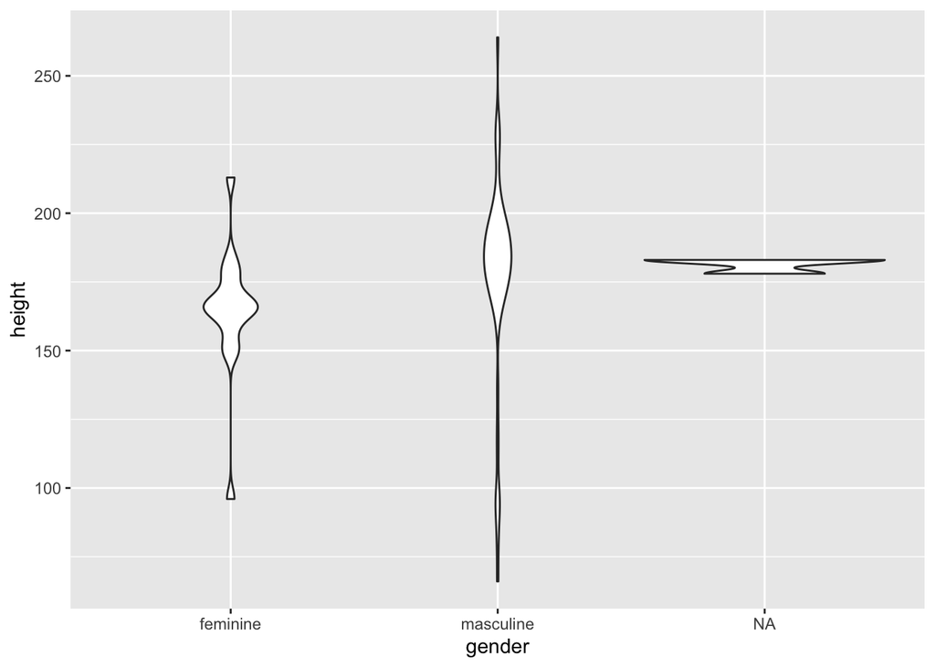

```r
ggplot(data = starwars, mapping = aes(y = height, x = gender)) +
  geom_violin()
```

### Jitter plot

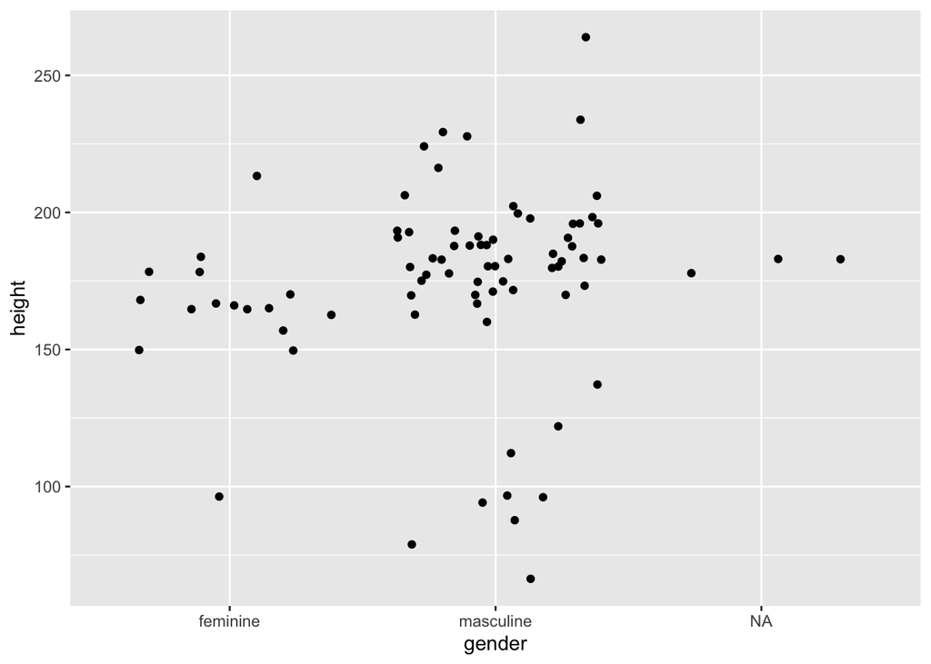

```r
ggplot(data = starwars, mapping = aes(y = height, x = gender)) +
  geom_jitter()
```

What does `geom_gitter` do?

### Scatterplot as columns

What is the average height for each species?

```r
dat <- starwars %>%
  group_by(species) %>%
  summarise(avg = mean(height, na.rm = T))
```

Let us visualize it

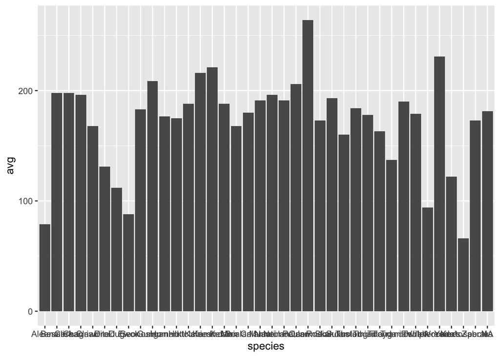

```r
dat %>% ggplot(aes(x = species, y = avg)) +
  geom_col()
```

Let us sort the columns, add labels and rotate the x-axis labels:

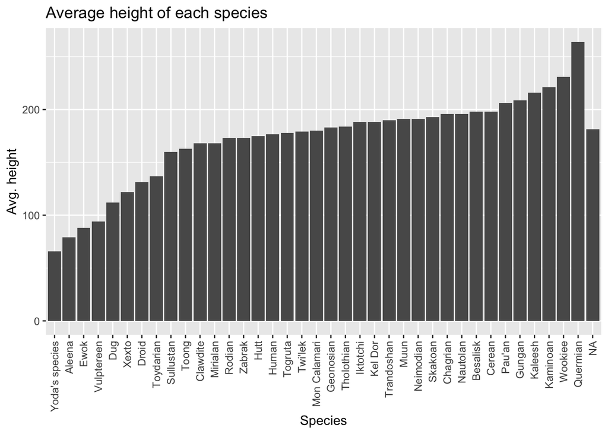

```r
dat %>%
  ggplot(aes(x = reorder(species, avg), y = avg)) +
  geom_col() +
  labs(title = "Average height of each species",
       x = "Species",
       y = "Avg. height"
    ) +
  theme(axis.text.x = element_text(angle = 90, vjust = 0.5, hjust=1))
```

## Visualizing relationships between numerical and numerical data

### Scatterplot

```r
starwars_without_jabba <- starwars %>% filter(mass < 500)
```

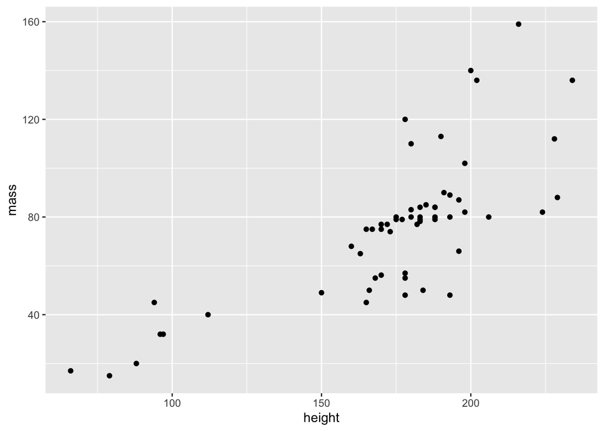

```r
ggplot(starwars_without_jabba, aes(x = height, y = mass)) +
  geom_point()
```

Let us try to add some linesd

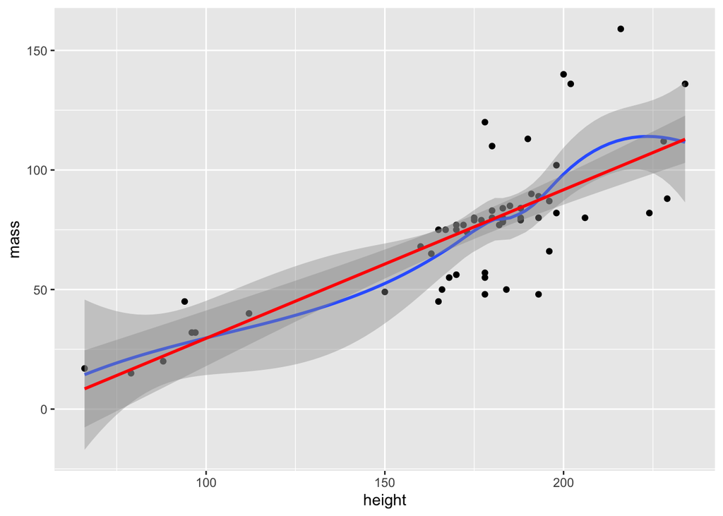

```r
ggplot(starwars_without_jabba, aes(x = height, y = mass)) +
  geom_point() +
  geom_smooth() +
  geom_smooth(method = "lm", color = "red")
```